# Final Project: 某闯关类手游用户流失预测

## 一、案例简介

手游在当下的日常娱乐中占据着主导性地位，成为人们生活中放松身心的一种有效途径。近年来，各种类型的手游，尤其是闯关类的休闲手游，由于其对碎片化时间的利用取得了非常广泛的市场。然而在此类手游中，新用户流失是一个非常严峻的问题，有相当多的新用户在短暂尝试后会选择放弃，而如果能在用户还没有完全卸载游戏的时候针对流失可能性较大的用户施以干预（例如奖励道具、暖心短信），就可能挽回用户从而提升游戏的活跃度和公司的潜在收益，因此用户的流失预测成为一个重要且挑战性的问题。在毕业项目中我们将从真实游戏中非结构化的日志数据出发，构建用户流失预测模型，综合已有知识设计适合的算法解决实际问题。

## 二、作业说明

根据给出的实际数据（包括用户游玩历史，关卡特征等），预测测试集中的用户是否为流失用户（二分类）； 方法不限，使用百度云进行评测，评价指标使用 AUC； 提交代码与实验报告，报告展示对数据的观察、分析、最后的解决方案以及不同尝试的对比等； 最终评分会参考达到的效果以及对所尝试方法的分析。

## 三、数据概览

本次使用的是一个休闲类闯关手游的数据，用户在游戏中不断闯关，每一关的基本任务是在限定步数内达到某个目标。每次闯关可能成功也可能失败，一般情况下用户只在完成一关后进入下一关，闯关过程中可以使用道具或提示等帮助。

对大多数手游来说，用户流失往往发生在早期，因此次周的留存情况是公司关注的一个重点。本次数据选取了 2020.2.1 注册的所有用户在 2.1-2.4 的交互数据，数据经过筛选保证这些注册用户在前四日至少有两日登录。流失的定义则参照次周（2.7-2.13）的登录情况，如果没有登录为流失。

本次的数据和以往结构化的形式不同，展现的是更原始的数据记录，更接近公司实际日志的形式，共包含 5 个文件：

### train.csv

```python
from sklearn.ensemble import RandomForestClassifier, AdaBoostClassifier, VotingClassifier, BaggingClassifier
from sklearn.naive_bayes import MultinomialNB, BernoulliNB, ComplementNB, GaussianNB
from sklearn import preprocessing, tree, ensemble, svm, metrics, calibration
from sklearn.metrics import roc_curve, auc, accuracy_score, roc_auc_score
from sklearn.neighbors import KNeighborsClassifier
from sklearn.preprocessing import StandardScaler
from sklearn.preprocessing import MinMaxScaler
```

```python
!pip install torchvision
```

```python
import torchvision, datetime, scipy, os, torch
from sklearn.feature_extraction import text
from matplotlib import pyplot as plt
from torch.autograd import Variable
from itertools import combinations
from collections import Counter
from torch.utils import data
from tqdm import tqdm
import torch.nn as nn
import seaborn as sns
import pandas as pd
import numpy as np
```

```python
train_df = pd.read_csv('./train.csv',sep='\t')
train_df.T
```

|  | 0 | 1 | 2 | 3 | 4 | 5 | 6 | 7 | 8 | 9 | ... | 8148 | 8149 | 8150 | 8151 | 8152 | 8153 | 8154 | 8155 | 8156 | 8157 |
| --- | --- | --- | --- | --- | --- | --- | --- | --- | --- | --- | --- | --- | --- | --- | --- | --- | --- | --- | --- | --- | --- |
| user_id | 2774 | 2775 | 2776 | 2777 | 2778 | 2779 | 2780 | 2781 | 2782 | 2783 | ... | 10922 | 10923 | 10924 | 10925 | 10926 | 10927 | 10928 | 10929 | 10930 | 10931 |
| label | 0 | 0 | 1 | 0 | 1 | 1 | 0 | 0 | 0 | 1 | ... | 0 | 0 | 0 | 1 | 1 | 1 | 1 | 0 | 1 | 0 |

2 rows × 8158 columns

```python
train_df['label'].value_counts()
```

```
0    5428
1    2730
Name: label, dtype: int64
```

### dev.csv

```python
dev_df = pd.read_csv('./dev.csv',sep='\t')
dev_df.T
```

|  | 0 | 1 | 2 | 3 | 4 | 5 | 6 | 7 | 8 | 9 | ... | 2648 | 2649 | 2650 | 2651 | 2652 | 2653 | 2654 | 2655 | 2656 | 2657 |
| --- | --- | --- | --- | --- | --- | --- | --- | --- | --- | --- | --- | --- | --- | --- | --- | --- | --- | --- | --- | --- | --- |
| user_id | 10932 | 10933 | 10934 | 10935 | 10936 | 10937 | 10938 | 10939 | 10940 | 10941 | ... | 13580 | 13581 | 13582 | 13583 | 13584 | 13585 | 13586 | 13587 | 13588 | 13589 |
| label | 0 | 1 | 0 | 1 | 0 | 0 | 0 | 0 | 0 | 1 | ... | 0 | 1 | 1 | 0 | 1 | 0 | 0 | 0 | 1 | 0 |

2 rows × 2658 columns

```python
dev_df['label'].value_counts()
```

```
0    1757
1     901
Name: label, dtype: int64
```

验证集对应的用户 ID 为 10932 - 13589

### test.csv

```python
test_df = pd.read_csv('./test.csv',sep = '\t' )
test_df.T
```

|  | 0 | 1 | 2 | 3 | 4 | 5 | 6 | 7 | 8 | 9 | ... | 2763 | 2764 | 2765 | 2766 | 2767 | 2768 | 2769 | 2770 | 2771 | 2772 |
| --- | --- | --- | --- | --- | --- | --- | --- | --- | --- | --- | --- | --- | --- | --- | --- | --- | --- | --- | --- | --- | --- |
| user_id | 1 | 2 | 3 | 4 | 5 | 6 | 7 | 8 | 9 | 10 | ... | 2764 | 2765 | 2766 | 2767 | 2768 | 2769 | 2770 | 2771 | 2772 | 2773 |

1 rows × 2773 columns

### level_seq.csv

用户行为的具体变量如下：

1. user_id：用户 id，和训练、验证、测试集中的可以匹配；
2. level_id：关卡 id；
3. f_success：是否通关（1：通关，0：失败）；
4. f_duration：此次尝试所用的时间（单位 s）；
5. f_reststep：剩余步数与限定步数之比（失败为 0）；
6. f_help：是否使用了道具、提示等额外帮助（1：使用，0：未使用）；
7. time：时间戳。

```python
seq_df = pd.read_csv('level_seq.csv',sep='\t')
seq_df
```

|  | user_id | level_id | f_success | f_duration | f_reststep | f_help | time |
| --- | --- | --- | --- | --- | --- | --- | --- |
| 0 | 10932 | 1 | 1 | 127.0 | 0.500000 | 0 | 2020-02-01 00:05:51 |
| 1 | 10932 | 2 | 1 | 69.0 | 0.703704 | 0 | 2020-02-01 00:08:01 |
| 2 | 10932 | 3 | 1 | 67.0 | 0.560000 | 0 | 2020-02-01 00:09:50 |
| 3 | 10932 | 4 | 1 | 58.0 | 0.700000 | 0 | 2020-02-01 00:11:16 |
| 4 | 10932 | 5 | 1 | 83.0 | 0.666667 | 0 | 2020-02-01 00:13:12 |
| ... | ... | ... | ... | ... | ... | ... | ... |
| 2194346 | 10931 | 40 | 1 | 111.0 | 0.250000 | 1 | 2020-02-03 16:26:37 |
| 2194347 | 10931 | 41 | 1 | 76.0 | 0.277778 | 0 | 2020-02-03 16:28:06 |
| 2194348 | 10931 | 42 | 0 | 121.0 | 0.000000 | 1 | 2020-02-03 16:30:17 |
| 2194349 | 10931 | 42 | 0 | 115.0 | 0.000000 | 0 | 2020-02-03 16:33:40 |
| 2194350 | 10931 | 42 | 1 | 91.0 | 0.181818 | 0 | 2020-02-03 16:35:18 |

2194351 rows × 7 columns

```python
sub = seq_df[seq_df['user_id'] == 233]
sub
```

|  | user_id | level_id | f_success | f_duration | f_reststep | f_help | time |
| --- | --- | --- | --- | --- | --- | --- | --- |
| 228497 | 233 | 1 | 1 | 25.0 | 0.500000 | 0 | 2020-02-01 06:16:06 |
| 228498 | 233 | 2 | 1 | 27.0 | 0.777778 | 0 | 2020-02-01 06:17:24 |
| 228499 | 233 | 3 | 1 | 35.0 | 0.680000 | 0 | 2020-02-01 06:18:07 |
| 228500 | 233 | 4 | 1 | 28.0 | 0.733333 | 0 | 2020-02-01 06:18:36 |
| 228501 | 233 | 5 | 1 | 44.0 | 0.583333 | 0 | 2020-02-01 06:19:22 |
| ... | ... | ... | ... | ... | ... | ... | ... |
| 228623 | 233 | 105 | 0 | 87.0 | 0.000000 | 0 | 2020-02-02 01:43:41 |
| 228624 | 233 | 105 | 0 | 93.0 | 0.000000 | 0 | 2020-02-02 01:45:15 |
| 228625 | 233 | 105 | 0 | 80.0 | 0.000000 | 0 | 2020-02-02 01:46:37 |
| 228626 | 233 | 105 | 0 | 82.0 | 0.000000 | 0 | 2020-02-02 01:48:00 |
| 228627 | 233 | 105 | 0 | 90.0 | 0.000000 | 0 | 2020-02-02 23:31:48 |

131 rows × 7 columns

```python
sub['f_success'].value_counts()
```

```
1    98
0    33
Name: f_success, dtype: int64
```

### level_meta.csv

关卡的具体变量如下：

1. f_avg_duration：平均每次尝试花费的时间（单位 s，包含成功与失败的尝试）；
2. f_avg_passrate：平均通关率；
3. f_avg_win_duration：平均每次通关花费的时间（单位 s，只包含通关的尝试）；
4. f_avg_retrytimes：平均重试次数（第二次玩同一关算第 1 次重试）；
5. level_id：关卡 id，可以和 level_seq.csv 中的关卡匹配。

```python
meta_df = pd.read_csv('./level_meta.csv', sep='\t')
meta_df
```

|  | f_avg_duration | f_avg_passrate | f_avg_win_duration | f_avg_retrytimes | level_id |
| --- | --- | --- | --- | --- | --- |
| 0 | 39.889940 | 0.944467 | 35.582757 | 0.017225 | 1 |
| 1 | 60.683975 | 0.991836 | 56.715706 | 0.004638 | 2 |
| 2 | 76.947355 | 0.991232 | 71.789943 | 0.004480 | 3 |
| 3 | 58.170347 | 0.993843 | 54.842882 | 0.004761 | 4 |
| 4 | 101.784577 | 0.954170 | 85.650547 | 0.027353 | 5 |
| ... | ... | ... | ... | ... | ... |
| 1504 | 594.878788 | 0.453730 | 133.625000 | 3.187500 | 1505 |
| 1505 | 486.562500 | 0.454180 | 115.906250 | 3.218750 | 1506 |
| 1506 | 325.968750 | 0.573525 | 86.250000 | 2.687500 | 1507 |
| 1507 | 793.096774 | 0.322684 | 164.000000 | 5.419355 | 1508 |
| 1508 | 423.406250 | 0.461409 | 106.833333 | 2.200000 | 1509 |

1509 rows × 5 columns

## 四、Tips

一个基本的思路可以是：根据游玩关卡的记录为每个用户提取特征 → 结合 label 构建表格式的数据集 → 使用不同模型训练与测试；还可以借助其他模型（如循环神经网络）直接对用户历史序列建模；数据量太大运行时间过长的话，可以先在一个采样的小训练集上调参；集成多种模型往往能达到更优的效果；可以使用各种开源工具。

#### 1. 数据预处理

重构变量突出用户行为：

- 上瘾程度：
  - day：登录天数，很多用户的留存原因是每日签到
  - login：登录次数，根据时间之差判断，是不是没事干就玩一下
  - endlogin：最后一天玩的局数
  - time：登录总花费的时间
  - try：尝试记录次数
- 游玩体验：
  - success：通关数/尝试次数
  - maxlevel：最大闯关数
  - maxwin：最大连赢数【剔除】
  - maxfail：最大连输数
  - winof20：最后20局的胜率
  - winof3：最后3局的胜率
  - retryend：最后重试次数【与retry相关性较强，剔除】
- 个人特性：
  - beginday：开始玩的时间【剔除】
  - help：使用帮助的频率【剔除】
  - retry：最大愿意重试的次数
  - duration：平均每一关超出平均时长
  - restep：成功通关的记录中，平均剩余步数与限定步数之比

```python
def cvttime(data):
    data_dict = {
        'year': int(data.split(' ')[0].split('-')[0]),
        'mooth': int(data.split(' ')[0].split('-')[1]),
        'day': int(data.split(' ')[0].split('-')[2]),
        'hour': int(data.split(' ')[1].split(':')[0]),
        'min': int(data.split(' ')[1].split(':')[1]),
        'sec': int(data.split(' ')[1].split(':')[2])
    }
    data = datetime.datetime(data_dict['year'],
                             data_dict['mooth'],
                             data_dict['day'],
                             data_dict['hour'],
                             data_dict['min'],
                             data_dict['sec'])
    return data
```

```python
seq_df['day'] = seq_df['time'].map(lambda x: int(x.split(' ')[0].split('-')[2]))
seq_df['time'] = seq_df['time'].map(lambda x:cvttime(x))
```

```python
f_avg = meta_df['f_avg_duration'].values
seq_df['exc_time'] = seq_df.apply(lambda x: x['f_duration']-f_avg[int(x['level_id']-1)], axis = 1)
```

```python
def cal_login(series):
    ans=1
    for start,end in zip(series[0::2],series[1::2],):
        if (end-start).total_seconds()>900:
            ans+=1
    return ans


def cal_fail_retry(df):
    win, fail, retry = 0, 0, 0
    max_win, max_fail, max_retry = 0, 0, 0
    tmplevel = df['level_id'].values[0]
    for idx, row in df.iterrows():
        if row['f_success'] == 0:
            fail+=1
            if fail>max_fail:
                max_fail = fail
            win = 0
        else:
            win+=1
            if win>max_win:
                max_win = win
            fail=0
        if row['level_id']==tmplevel:
            retry+=1
            if retry > max_retry:
                max_retry = retry
        else:
            tmplevel = row['level_id']
            retry = 0
    return max_win, max_fail, max_retry
```

```python
user_df = seq_df.groupby(['user_id'])
train_X, valid_X, test_X = [], [], []
train_y, valid_y, test_y = [], [], []
for userid, df in tqdm(user_df):
    user = []
    user.append(len(set(df['day'])))
    login = cal_login(df['time'])
    user.append(login)
    user.append(df[df['day']==max(df['day'])].shape[0])
    user.append(sum(df['f_duration']))
    try_ = df.shape[0]
    user.append(try_)
    user.append(np.nanmean(df['f_success']))
    user.append(max(df['level_id']))
    win, fail, retry = cal_fail_retry(df)
    # user.append(win)
    user.append(fail)
    user.append(np.nanmean(df['f_success'][-20 if try_>20 else 0:]))
    user.append(np.nanmean(df['f_success'][-3 if try_ > 3 else 0:]))
    # user.append(np.nanmean(df['f_success'].values[-1]))
    # user.append(min(df['day']))
    # user.append(np.nanmean(df['f_help']))
    user.append(retry)
    user.append(np.nanmean(df['exc_time']))
    if not df[df['f_success'] == 1].shape[0]:
        user.append(0)
    else:
        user.append(np.nanmean(df[df['f_success'] == 1]['f_reststep']))
    if userid in set(train_df['user_id']):
        train_X.append(user)
        train_y.append(train_df[train_df['user_id'] == userid]['label'])
    elif userid in set(dev_df['user_id']):
        valid_X.append(user)
        valid_y.append(dev_df[dev_df['user_id'] == userid]['label'])
    else:
        test_X.append(user)
```

```python
train_X, valid_X, test_X = np.array(
    train_X), np.array(valid_X), np.array(test_X)
train_y, valid_y, test_y = np.array(
    train_y), np.array(valid_y), np.array(test_y)
```

```python
print(train_X.shape, train_y.shape)
print(valid_X.shape, valid_y.shape)
print(test_X.shape, test_y.shape)
```

```
(8158, 13) (8158, 1)
(2658, 13) (2658, 1)
(2773, 13) (0,)
```

```python
feature_df = pd.DataFrame(np.concatenate((train_X, train_y),axis =1), columns=['day', 'login', 'endlogin', 'time', 'try', 'success', 'maxlevel', 'maxfail', 'winof20', 'winof3', 'retry', 'duration', 'restep', 'label'])
```

```python
feature_df.describe()
```

|  | day | login | endlogin | time | try | success | maxlevel | maxfail | winof20 | winof3 | retry | duration | restep | label |
| --- | --- | --- | --- | --- | --- | --- | --- | --- | --- | --- | --- | --- | --- | --- |
| count | 8158.000000 | 8158.000000 | 8158.000000 | 8158.000000 | 8158.000000 | 8158.000000 | 8158.000000 | 8158.00000 | 8158.000000 | 8158.000000 | 8158.000000 | 8158.000000 | 8158.000000 | 8158.000000 |
| mean | 3.178475 | 5.455994 | 36.354989 | 17479.688772 | 161.776538 | 0.673581 | 129.745894 | 7.17443 | 0.528459 | 0.435769 | 7.435891 | -103.787820 | 0.322834 | 0.334641 |
| std | 0.848463 | 4.109535 | 49.185470 | 19474.149335 | 184.456500 | 0.192768 | 113.298225 | 11.03897 | 0.269326 | 0.362118 | 12.830445 | 108.102283 | 0.091907 | 0.471894 |
| min | 2.000000 | 1.000000 | 1.000000 | 22.000000 | 2.000000 | 0.000000 | 1.000000 | 0.00000 | 0.000000 | 0.000000 | 1.000000 | -822.308533 | 0.000000 | 0.000000 |
| 25% | 2.000000 | 2.000000 | 7.000000 | 4332.000000 | 44.000000 | 0.528976 | 39.000000 | 2.00000 | 0.300000 | 0.000000 | 2.000000 | -145.989994 | 0.253997 | 0.000000 |
| 50% | 3.000000 | 4.000000 | 19.000000 | 11737.500000 | 107.000000 | 0.680000 | 122.000000 | 5.00000 | 0.500000 | 0.333333 | 5.000000 | -72.764288 | 0.300037 | 0.000000 |
| 75% | 4.000000 | 7.000000 | 45.000000 | 24300.250000 | 211.000000 | 0.827586 | 178.000000 | 9.00000 | 0.750000 | 0.666667 | 9.000000 | -27.431674 | 0.375638 | 1.000000 |
| max | 4.000000 | 31.000000 | 628.000000 | 534421.000000 | 4122.000000 | 1.000000 | 1509.000000 | 394.00000 | 1.000000 | 1.000000 | 426.000000 | 342.713043 | 0.777778 | 1.000000 |

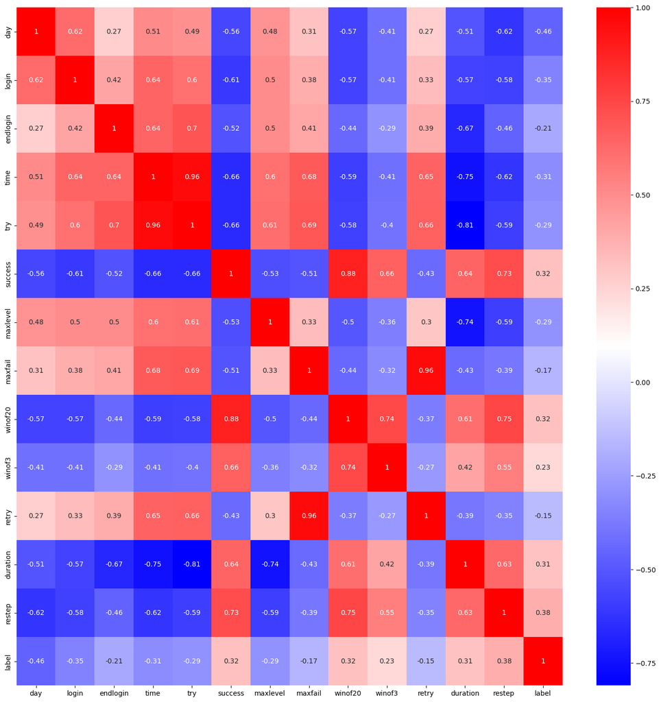

```python
# 热力图
plt.subplots(figsize=(18, 18))
sns.heatmap(feature_df.corr().round(2), cmap='bwr', annot=True)
```

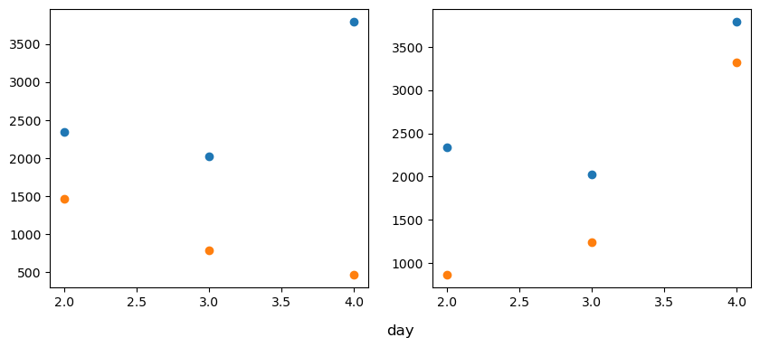

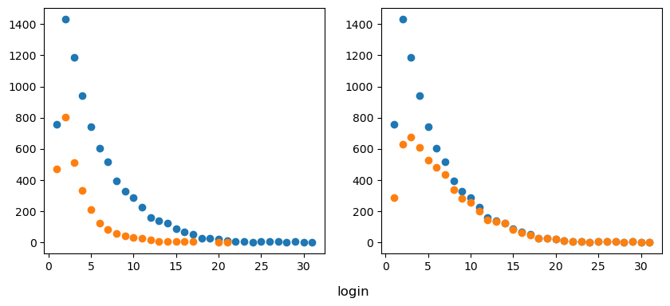

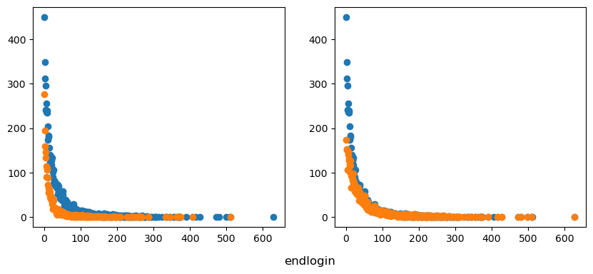

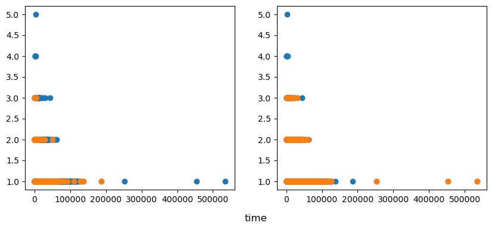

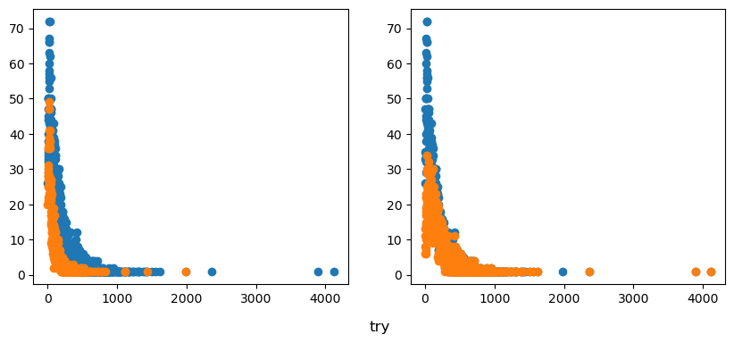

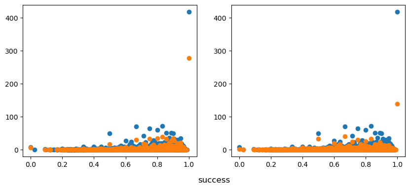

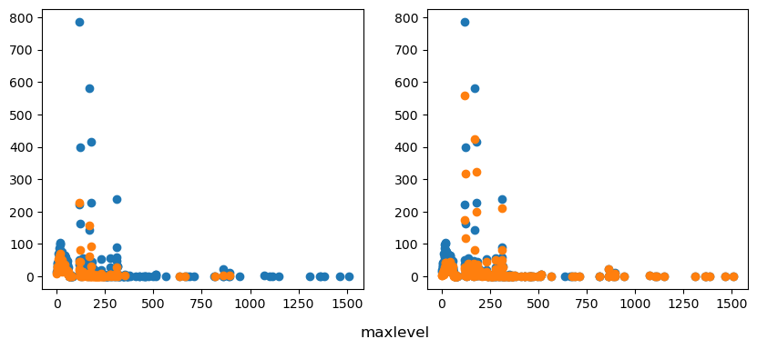

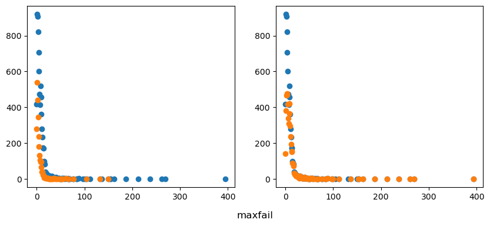

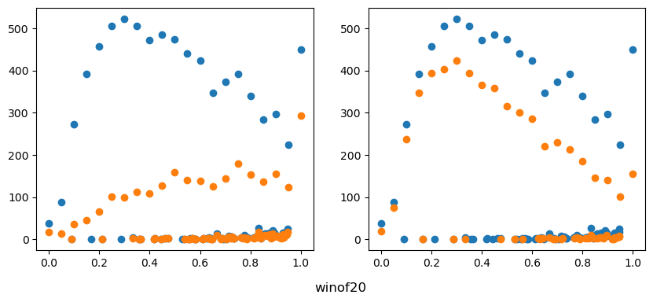

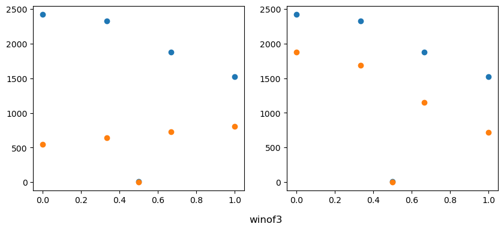

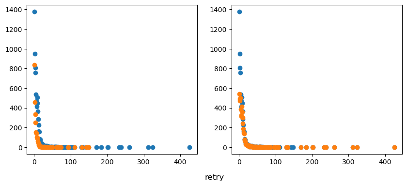

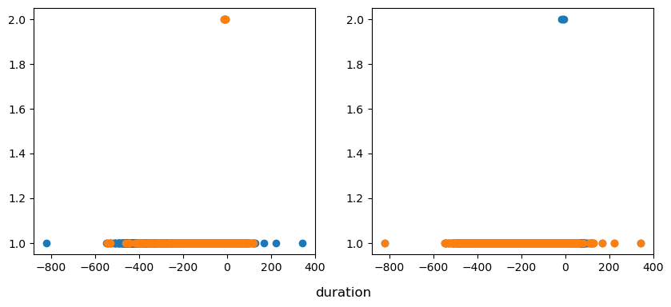

[2 more figures not shown]

```python
for co in feature_df.columns:
    a = Counter(feature_df[co])
    t = Counter(feature_df[train_df['label'] == 1][co])
    f = Counter(feature_df[train_df['label'] == 0][co])
    plt.figure(figsize=(10, 4))
    plt.subplot(121)
    plt.scatter(a.keys(), a.values())
    plt.scatter(t.keys(), t.values())
    plt.subplot(122)
    plt.scatter(a.keys(), a.values())
    plt.scatter(f.keys(), f.values())
    plt.title(co, x=-0.1, y=-0.2)
    plt.show()
```

#### 2. 模型搭建

```python
# 数据归一化
scaler = MinMaxScaler()
train_x = np.array(scaler.fit_transform(train_X))
valid_x = np.array(scaler.transform(valid_X))
test_x = np.array(scaler.transform(test_X))
```

```python
clfs = dict()
clfs['LinearSVM'] = calibration.CalibratedClassifierCV(
    svm.LinearSVC(loss='squared_hinge', dual=False))
# clfs['SVC'] = svm.SVC(kernel='rbf', probability=True)
clfs['DecisionTree'] = tree.DecisionTreeClassifier(
    criterion='gini', max_depth=5, splitter='random')
clfs['GaussianNB'] = GaussianNB()
clfs['MultBayes'] = MultinomialNB(
    alpha=1, fit_prior=True)
clfs['Knn'] = KNeighborsClassifier(n_neighbors=5)
```

```python
#结果对比
for name, clf in clfs.items():
    bcclf = BaggingClassifier(base_estimator=clf, n_estimators=50, max_samples=0.7,
                            max_features=0.4, bootstrap=True, bootstrap_features=True, n_jobs=1, random_state=1)
    bcclf.fit(train_x, train_y.flatten())
    pre = [x[1] for x in bcclf.predict_proba(valid_x)]
    fpr, tpr, thresholds = metrics.roc_curve(valid_y.flatten(), pre, pos_label=1)
    auc = metrics.auc(fpr, tpr)
    print("Bagging", name, auc)
    if name!='Knn':
        adclf = AdaBoostClassifier(base_estimator=clf, n_estimators=30,learning_rate=1,algorithm='SAMME.R')
        adclf.fit(train_x, train_y.flatten())
        pre = [x[1] for x in adclf.predict_proba(valid_x)]
        fpr, tpr, thresholds = metrics.roc_curve(
            valid_y.flatten(), pre, pos_label=1)
        auc = metrics.auc(fpr, tpr)
        print("Boosting", name, auc)
    print()
```

```
Bagging LinearSVM 0.777701624136086
Boosting LinearSVM 0.7799169581385889

Bagging DecisionTree 0.7807485769621689
Boosting DecisionTree 0.7472526257740562

Bagging GaussianNB 0.7610168174614053
Boosting GaussianNB 0.5328427845617687

Bagging MultBayes 0.7788411914416222
Boosting MultBayes 0.7786813740756018

Bagging Knn 0.7747914320204516
```

```python
rfclf = RandomForestClassifier(n_estimators=200,bootstrap=True)
rfclf.fit(train_x, train_y.flatten())
pre = [x[1] for x in rfclf.predict_proba(valid_x)]
fpr, tpr, thresholds = metrics.roc_curve(
    valid_y.flatten(), pre, pos_label=1)
auc = metrics.auc(fpr, tpr)
print("RandomForest",  auc)
```

```
RandomForest 0.781843926024142
```

```python
vclf = VotingClassifier(estimators=clfs.items(), voting='soft')
vclf.fit(train_x, train_y.flatten())
```

```
VotingClassifier(estimators=dict_items([('LinearSVM', CalibratedClassifierCV(base_estimator=LinearSVC(dual=False))), ('DecisionTree', DecisionTreeClassifier(max_depth=5, splitter='random')), ('GaussianNB', GaussianNB()), ('MultBayes', MultinomialNB(alpha=1)), ('Knn', KNeighborsClassifier())]),
                 voting='soft')
```

```python
pre = [x[1] for x in vclf.predict_proba(valid_x)]
fpr, tpr, thresholds = metrics.roc_curve(
    valid_y.flatten(), pre, pos_label=1)
auc = metrics.auc(fpr, tpr)
print("VotingClassifier",  auc)
```

```
VotingClassifier 0.7781709692070469
```

```python
new_x = np.concatenate([train_x, valid_x], axis = 0)
new_y = np.concatenate([train_y, valid_y], axis = 0)
print(new_x.shape, new_y.shape)
```

```
(10816, 13) (10816, 1)
```

```python
clf = clfs['DecisionTree']
bcclf = BaggingClassifier(base_estimator=clf, n_estimators=150, max_samples=0.2,
                          max_features=0.8, bootstrap=True, bootstrap_features=False, n_jobs=1, random_state=1)
bcclf.fit(new_x, new_y.flatten())
pre = [round(x[1],3) for x in bcclf.predict_proba(test_x)]
pre
```

[output not shown]

[output cut: 946 more lines]

[output not shown]

```python
 # 提交文件
import csv
with open('./result.csv', 'w', newline='') as csvfile:
    writer = csv.writer(csvfile)
    writer.writerow(['user_id', 'proba'])
    for idx, row in zip(test_df['user_id'].values, pre):
        writer.writerow([idx, row])
```